# Datenvisualisierung

7. Oktober 2017

## ggplot2 - Layered Grammar of Graphics

## Die Idee

Die Idee ist, jedes Diagramm nach dem gleichen Schema aufzubauen und nach und nach die Komponenten hinzuzufügen.

- [ggplot2: Elegant Graphics for Data Analysis](https://www.amazon.de/ggplot2-Elegant-Graphics-Data-Analysis/dp/331924275X/ref=sr_1_1?ie=UTF8&qid=1492538063&sr=8-1&keywords=ggplot2): Gibt ein tieferes Verständnis von **ggplot2**.

Konkret geht es um folgende Aspekte:

- **Data:** Welche Daten sollen dargestellt werden? Nicht so einfach, wie man denkt.
- **Aesthetic mapping:** Auf welcher Achse soll welche Variable dargestellt werden? Es gibt mehr als nur x- und y-Achse (Farbe, Größe, Transparenz, Form, …).
- **Scales::** WIE soll die jeweilige Achse skaliert sein? Logarithmisch, Farbpalette, …
- **Statistical transformation:** Sollen die Rohdaten dargestellt werden oder *prozessierte* Daten: Regressionslinien, Boxplots, Histogramme, …
- **Geometric Objects:** In welche Form sollen die Daten dargestellt werden? Z.B. Linien, Punkte, Balken, …
- **Positional adjustments:** Sollen Säulen z.B. über- oder nebeneinander dargestellt werden? Kartesisches oder Polarkoordinatensystem? Facetting?

## Data

```r
head(iris)
```

```
##   Sepal.Length Sepal.Width Petal.Length Petal.Width Species
## 1          5.1         3.5          1.4         0.2  setosa
## 2          4.9         3.0          1.4         0.2  setosa
## 3          4.7         3.2          1.3         0.2  setosa
## 4          4.6         3.1          1.5         0.2  setosa
## 5          5.0         3.6          1.4         0.2  setosa
## 6          5.4         3.9          1.7         0.4  setosa
```

## Statistical Transformation

Wir haben Glück!

- In der Regel kümmert ggplot sich um diesen Aspekt, ohne dass wir das merken!
- Trotzdem lohnt es sich, sich der Tatsache bewusst zu sein, dass etwas passiert!

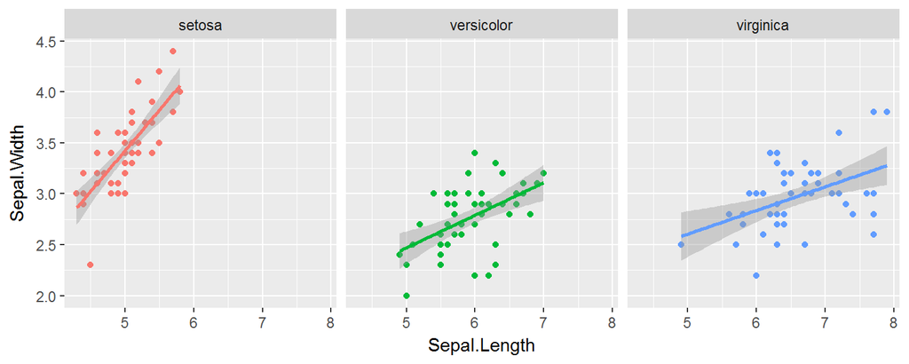

## Aesthetic Mapping

Dies ist einer der wichtigsten Punkte!

- Datensätze bestehen meist aus mehreren Variablen. Welche Variable wird auf welcher Skala dargestellt!
- Etwas klarer: Einen großen Wert kann man nicht nur dadurch darstellen, dass er sich sehr weit rechts (x-Achse) oder oben (y-Achse) auf einer räumlichen Skala befindet. Ein großer Wert kann auch
  - rot sein, während kleine Werte blau sind.
  - deckend sein, während kleine Werte transparent sind.
  - ein großer Punkt sein, während kleine Werte kleinere Punkte sind.
- Das gleiche funktioniert natürlich auch mit diskreten Variablen.

## Aesthetic Mapping: Ein Beispiel

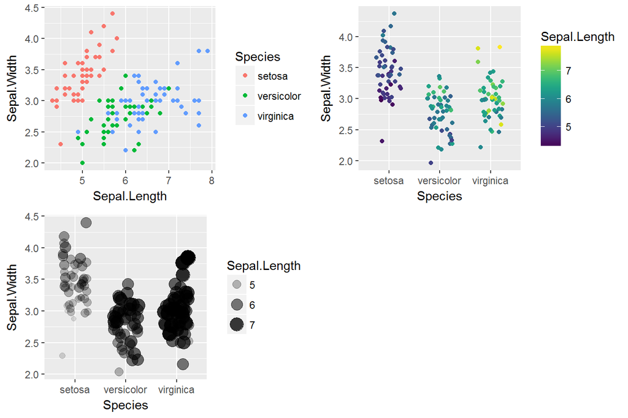

## Scales

Wir wissen jetzt, dass man Variablen auf verschiedene Skalen *mappen* kann. Aber jede Skala kann man unterschiedlich formatieren:

- Soll die x- oder y-Achse linear, logarithmisch oder exponentiell sein?
- Soll die Farbpalette von blau nach gelb verlaufen oder doch lieber von schwarz zu weiß?

## Scales: Ein Beispiel

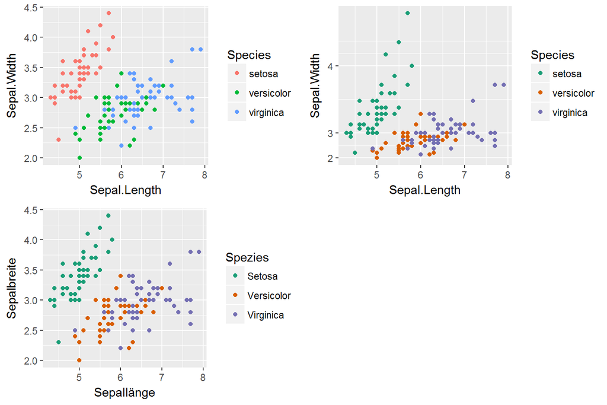

## Scales: Farbe

Welche Kriterien sollte man bei der Farbwahl beachten?

- Farbpaletten sollten eine große Spannweite haben, um feine Unterschiede auflösen zu können.
- Farben sollten auch von Personen mit Farbenfehlsichtigkeit unterschieden werden können.
- Farben sollten auch im Graustufen-Druck unterscheidbar sein.
- Die Farben sollten hübsch sein! :) Im Ernst: Es geht darum, den Leser auf seine Seite zu ziehen, und hübsche Farben wirken professioneller.
- Diese Kriterien werden von den Farbpaletten aus dem `viridis`-Paket erfüllt!

## Geometric Objects

Schließlich noch das (nicht ganz so) Offensichtliche:

Mit welchem **geometrischen Objekt** stelle ich meine Daten dar?

- Punkte
- Linien
- Balken
- Boxplot
- Konturen
- Hexagone
- …

## Geometric Objects: Ein Beispiel

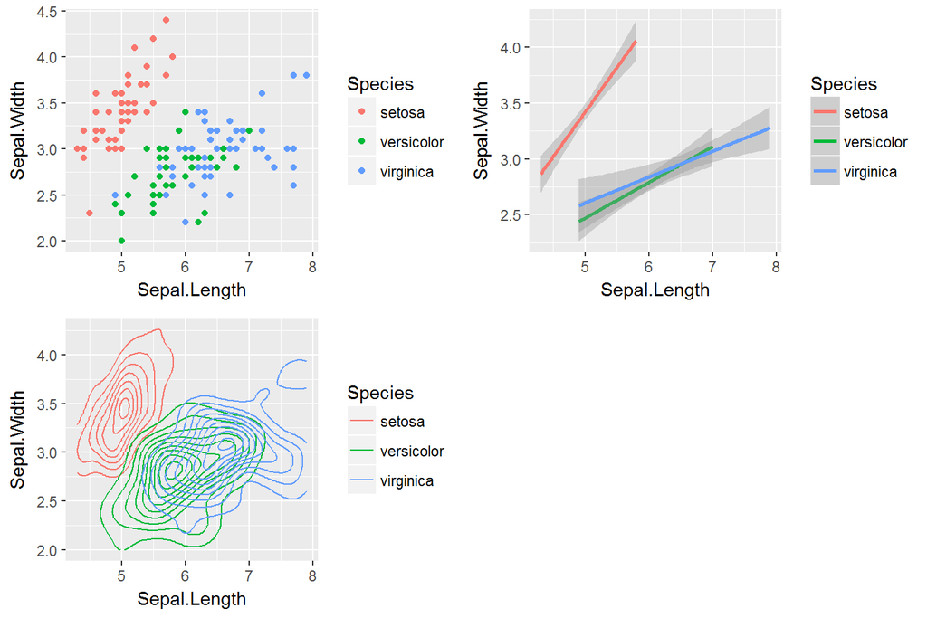

## Positional Adjustments

> Die Frage nach dem Koordinatensystem, dem **Facetting** und der Positionierung überlappener Punkte/Säulen/…

## Positional Adjustments: Ein Beispiel

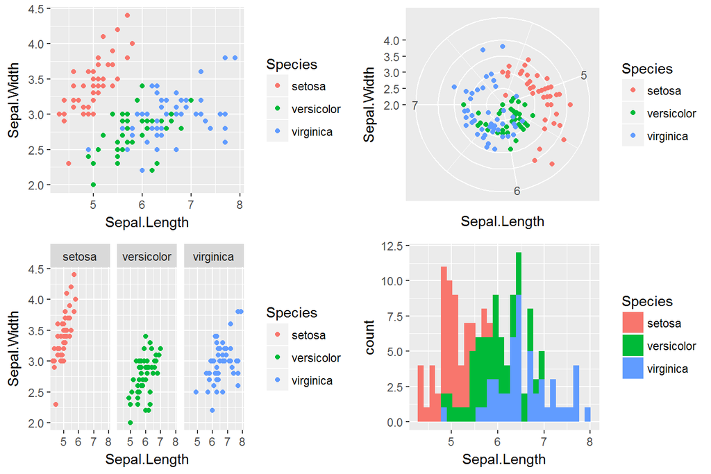

## Alles klar soweit?

- Dann eine kurze Pause!

## Euer erstes Diagramm mit R!

## Der Datensatz

```r
head(iris)
```

```
##   Sepal.Length Sepal.Width Petal.Length Petal.Width Species
## 1          5.1         3.5          1.4         0.2  setosa
## 2          4.9         3.0          1.4         0.2  setosa
## 3          4.7         3.2          1.3         0.2  setosa
## 4          4.6         3.1          1.5         0.2  setosa
## 5          5.0         3.6          1.4         0.2  setosa
## 6          5.4         3.9          1.7         0.4  setosa
```

```r
View(iris)
```

## Nun kommt der Plot, Schritt für Schritt

> Jedes Diagramm startet mit der Funktion **ggplot()**.
- Das erste Argument ist IMMER **data**.

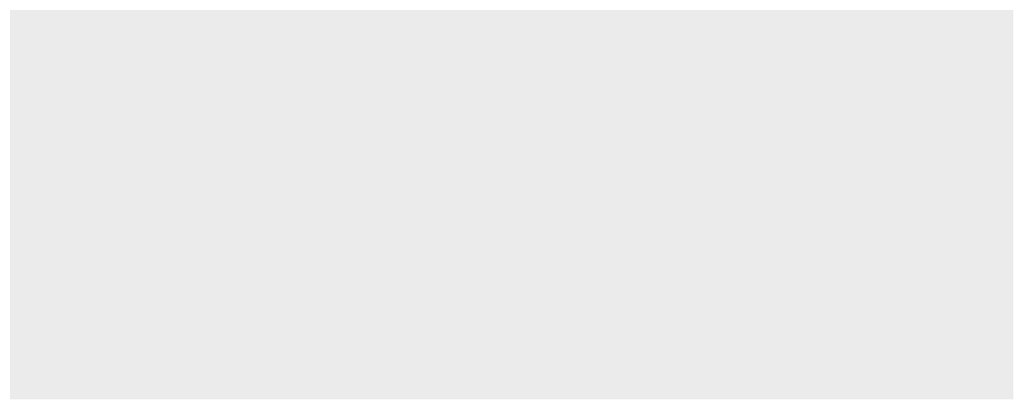

```r
ggplot(data = iris)
```

## Der Plot: Die Mappings

> Die Variablen werden über das Argument **mapping = aes()** auf die Achsen gemapped.
- Das zweite Argument ist IMMER **mapping**.

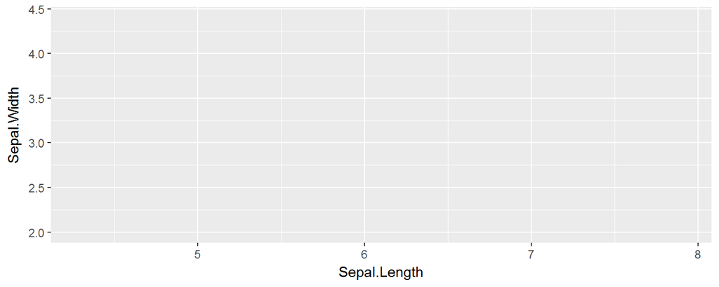

```r
ggplot(data = iris, mapping = aes(x = Sepal.Length, y = Sepal.Width, colour = Species))
```

## Der Plot: Die Geometric Objects

Weitere Eigenschaften können über ein **+** hinter der letzten Zeile hinzugefügt werden!

> Geometric objects fangen IMMER mit **geom_** an.

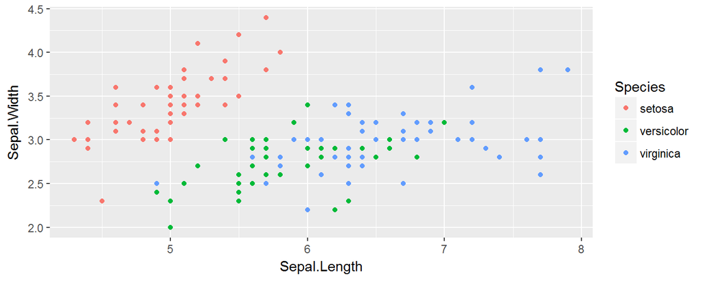

```r
ggplot(data = iris, mapping = aes(x = Sepal.Length, y = Sepal.Width, colour = Species)) +
  geom_point()
```

## Der Plot: Statistical Transformations

> Statistical Transformations kann man immer über **stat_** hinzufügen.

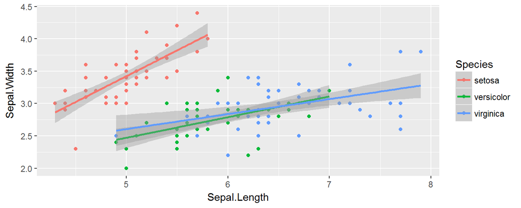

```r
ggplot(data = iris, mapping = aes(x = Sepal.Length, y = Sepal.Width, colour = Species)) +
  geom_point() +
  stat_smooth(method = "lm")
```

## Der Plot: Scales

> Über Scales kann man alles ändern, was mit Achsen etc. zu tun hat. Sie werden immer über **scale_** aufgerufen!

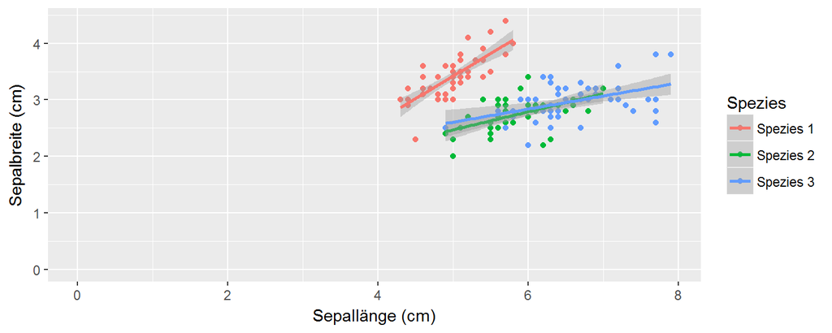

```r
ggplot(data = iris, mapping = aes(x = Sepal.Length, y = Sepal.Width, colour = Species)) +
  geom_point() +
  stat_smooth(method = "lm") +
  scale_x_continuous(name = "Sepallänge (cm)", limits = c(0,NA)) +
  scale_y_continuous(name = "Sepalbreite (cm)", limits = c(0,NA)) +
  scale_colour_discrete(name = "Spezies", labels = c("Spezies 1", "Spezies 2", "Spezies 3"))
```

## Positional Adjustments

Hier schauen wir uns für den moment nur das **Facetting** an:

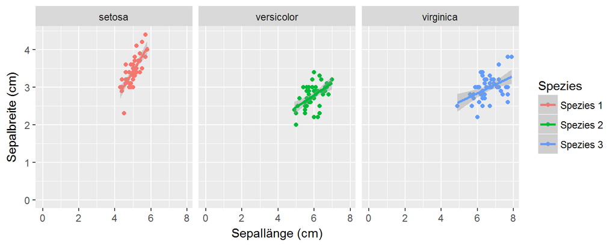

```r
ggplot(data = iris, mapping = aes(x = Sepal.Length, y = Sepal.Width, colour = Species)) +
  geom_point() +
  stat_smooth(method = "lm") +
  scale_x_continuous(name = "Sepallänge (cm)", limits = c(0,NA)) +
  scale_y_continuous(name = "Sepalbreite (cm)", limits = c(0,NA)) +
  scale_colour_discrete(name = "Spezies", labels = c("Spezies 1", "Spezies 2", "Spezies 3")) +
  facet_wrap(~ Species, ncol = 3)
```

## Das Theme

Zuletzt kann man dem Plot noch ein anderes Standard-Theme geben und gleichzeitig die Textgröße anpassen:

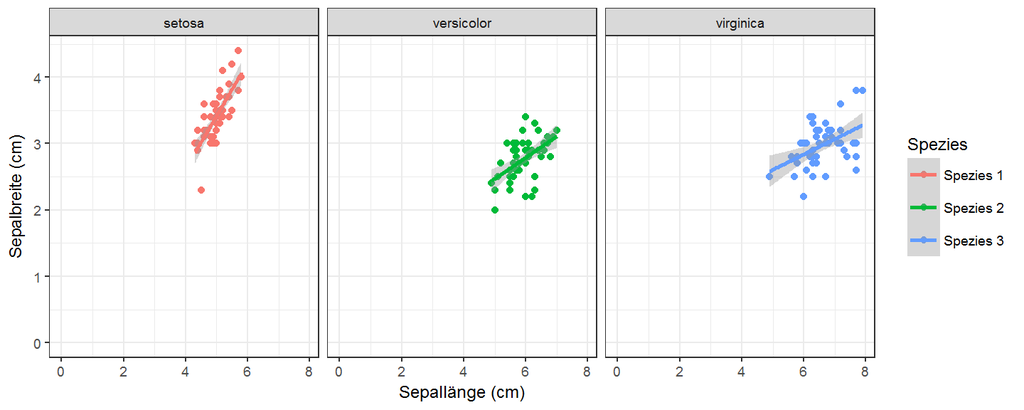

```r
ggplot(data = iris, mapping = aes(x = Sepal.Length, y = Sepal.Width, colour = Species)) +
  geom_point() +
  stat_smooth(method = "lm") +
  scale_x_continuous(name = "Sepallänge (cm)", limits = c(0,NA)) +
  scale_y_continuous(name = "Sepalbreite (cm)", limits = c(0,NA)) +
  scale_colour_discrete(name = "Spezies", labels = c("Spezies 1", "Spezies 2", "Spezies 3")) +
  facet_wrap(~ Species, ncol = 3) +
  theme_bw(base_size = 9)
```

## Den Plot speichern

Den Plot kann man anschließend mit der `ggsave()`-Funktion speichern:

```r
ggsave(filename = "./Results/Plot.png",
       plot = last_plot(),
       width = 80, height = 60,
       units = "mm",
       dpi = 600)
```

## Was es beim Speichern zu beachten gibt

- Wenn möglich, den Plot als Vektorgrafik speichern: `filename = ".../Plot.pdf"` oder `filename = ".../Plot.svg"`.
- Soll die Auflösung bei Rastergrafiken erhöht werden, wird dies über das Argument `dpi` gemacht. **NIEMALS** über `width` und/oder `height`.
- Messt in euren Dokumenten mal nach, wie breit der Textbereich ist und orientiert die Größe des Plots daran. So ist die Schrift in allen Diagrammen im späteren Protokoll gleich groß.